# 重賞レース予測レポート【毎時自動更新中】

作成日時: 2025/08/10 16:06:31

☞ [マニュアル(pdf)](https://ryutoro-galois.github.io/keiba-predictor/manual/manual.pdf)

☞ 過去5年の同一レース結果: [2024年](https://ryutoro-galois.github.io/keiba-predictor/report/PredResult_2024y_raceDate_20240804_20240804.html), [2023年](https://ryutoro-galois.github.io/keiba-predictor/report/PredResult_2023y_raceDate_20230806_20230806.html), [2022年](https://ryutoro-galois.github.io/keiba-predictor/report/PredResult_2022y_raceDate_20220807_20220807.html), [2021年](https://ryutoro-galois.github.io/keiba-predictor/report/PredResult_2021y_raceDate_20210808_20210808.html), [2020年](https://ryutoro-galois.github.io/keiba-predictor/report/PredResult_2020y_raceDate_20200809_20200809.html)

☞ 過去4週間の別レース結果: [1週前(8/3)](https://ryutoro-galois.github.io/keiba-predictor/report/PredResult_2025y_raceDate_20250803_20250803.html), [2週前(7/27)](https://ryutoro-galois.github.io/keiba-predictor/report/PredResult_2025y_raceDate_20250727_20250727.html), [3週前(7/20)](https://ryutoro-galois.github.io/keiba-predictor/report/PredResult_2025y_raceDate_20250720_20250720.html), [4週前(7/13)](https://ryutoro-galois.github.io/keiba-predictor/report/PredResult_2025y_raceDate_20250713_20250713.html)

☞ netkeiba: [エルムステークス(GⅢ)](https://race.netkeiba.com/race/shutuba.html?race_id=202501010511&rf=race_list), [レパードステークス(GⅢ)](https://race.netkeiba.com/race/shutuba.html?race_id=202504020607&rf=race_list), [CBC賞(GⅢ)](https://race.netkeiba.com/race/shutuba.html?race_id=202507030607&rf=race_list)

## 0. 推し馬予測 (AI予測)

### 【エルムステークス(GⅢ) 2025/08/09(土)】

- 本命(◎): 1-3着内確率(勝負強さ)が1位の馬
- 対抗(◯): 1-3着内確率が2-N位(20%程度以上)の中で予測タイムが最も速い馬
- 3番手(▲): 1-3着内確率が2-N位(20%程度以上)のでダークホース確率が最も高い馬
- 穴: ダークホース確率が上位1-M位(40%程度以上)の中で1-3着内確率が最も高い馬

| 推し馬 | 枠番 | 馬番 | 人気 | オッズ | 馬名 | 騎手 | 調教師 | 予測タイム(sec) | 1_順位 | 1-3着内確率(%) | 2_順位 | ﾀﾞｰｸﾎｰｽ確率(%) | 3_順位 |
| --- | --- | --- | --- | --- | --- | --- | --- | --- | --- | --- | --- | --- | --- |
| 本命(◎) | 1 | 1 | 5 | 8.9 | ペリエール | 佐々木大輔 | 黒岩陽一 | 107.0 | 4 | 25.3 | 1 | 1.7 | 8 |
| 対抗(◯) | 4 | 6 | 1 | 2.6 | ロードクロンヌ | 藤岡佑介 | 四位洋文 | 100.9 | 1 | 24.3 | 2 | 0.5 | 14 |
| 3番手(▲) | 6 | 10 | 4 | 8.5 | トロヴァトーレ | Ｃ．ルメール | 鹿戸雄一 | 104.9 | 2 | 21.9 | 3 | 1.4 | 10 |
| 穴 | 5 | 7 | 9 | 18.6 | テーオードレフォン | 丸山元気 | 梅田智之 | 108.7 | 10 | 16.4 | 5 | 22.4 | 2 |

### 【レパードステークス(GⅢ) 2025/08/10(日)】

- 本命(◎): 1-3着内確率(勝負強さ)が1位の馬
- 対抗(◯): 1-3着内確率が2-N位(20%程度以上)の中で予測タイムが最も速い馬
- 3番手(▲): 1-3着内確率が2-N位(20%程度以上)のでダークホース確率が最も高い馬
- 穴: ダークホース確率が上位1-M位(40%程度以上)の中で1-3着内確率が最も高い馬

| 推し馬 | 枠番 | 馬番 | 人気 | オッズ | 馬名 | 騎手 | 調教師 | 予測タイム(sec) | 1_順位 | 1-3着内確率(%) | 2_順位 | ﾀﾞｰｸﾎｰｽ確率(%) | 3_順位 |
| --- | --- | --- | --- | --- | --- | --- | --- | --- | --- | --- | --- | --- | --- |
| 本命(◎) | 7 | 13 | 2 | 4.9 | ルグランヴァン | 原優介 | 高木登 | 116.8 | 15.0 | 46.8 | 1 | 0.4 | 14 |
| 対抗(◯) | 5 | 9 | 3 | 5.5 | ロードラビリンス | 川田将雅 | 松下武士 | 116.6 | 3.0 | 34.4 | 2 | 0.4 | 13 |
| 3番手(▲) | 1 | 1 | 5 | 8.9 | ドンインザムード | 松山弘平 | 今野貞一 | 116.7 | 13.5 | 20.3 | 4 | 2.0 | 8 |
| 穴 | 2 | 3 | 13 | 58.5 | タガノマカシヤ | 菊沢一樹 | 中村直也 | 116.7 | 7.5 | 8.1 | 13 | 43.1 | 1 |

### 【CBC賞(GⅢ) 2025/08/10(日)】

- 本命(◎): 1-3着内確率(勝負強さ)が1位の馬
- 対抗(◯): 1-3着内確率が2-N位(20%程度以上)の中で予測タイムが最も速い馬
- 3番手(▲): 1-3着内確率が2-N位(20%程度以上)のでダークホース確率が最も高い馬
- 穴: ダークホース確率が上位1-M位(40%程度以上)の中で1-3着内確率が最も高い馬

| 推し馬 | 枠番 | 馬番 | 人気 | オッズ | 馬名 | 騎手 | 調教師 | 予測タイム(sec) | 1_順位 | 1-3着内確率(%) | 2_順位 | ﾀﾞｰｸﾎｰｽ確率(%) | 3_順位 |
| --- | --- | --- | --- | --- | --- | --- | --- | --- | --- | --- | --- | --- | --- |
| 本命(◎) | 7 | 14 | 2 | 4.2 | ヤマニンアルリフラ | 団野大成 | 斉藤崇史 | 70.5 | 3 | 44.9 | 1 | 0.5 | 17 |
| 対抗(◯) | 3 | 5 | 4 | 12.0 | シュトラウス | 杉原誠人 | 武井亮 | 71.8 | 8 | 41.4 | 2 | 1.6 | 9 |
| 3番手(▲) | 8 | 17 | 5 | 13.9 | インビンシブルパパ | 佐々木大輔 | 伊藤大士 | 71.1 | 6 | 14.3 | 4 | 1.3 | 12 |
| 穴 | 6 | 12 | 10 | 23.9 | エイシンワンド | 吉村誠之助 | 大久保龍志 | 70.4 | 2 | 7.7 | 8 | 26.6 | 4 |

## 1. 予測チャート (タイム/勝負強さ)

### 【エルムステークス(GⅢ)】

2025/08/09(土), 01_札幌, ダ右1700m

[interactive chart not shown]

### 【レパードステークス(GⅢ)】

2025/08/10(日), 04_新潟, ダ左1800m

[interactive chart not shown]

### 【CBC賞(GⅢ)】

2025/08/10(日), 07_中京, 芝左1200m

[interactive chart not shown]

## 2. オッズモニタリング (毎時)

### 【エルムステークス】

[interactive chart not shown]

### 【レパードステークス】

[interactive chart not shown]

### 【CBC賞】

[interactive chart not shown]

## 3. 出馬表

### 【エルムステークス 2025/08/09(土) 】

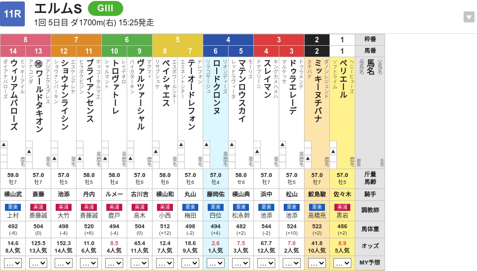

### 【レパードステークス 2025/08/10(日) 】

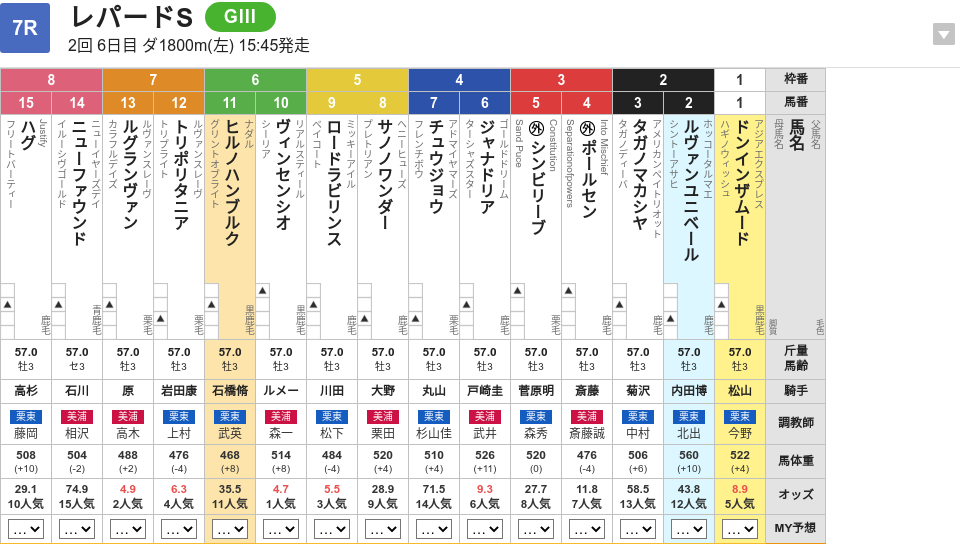

### 【CBC賞 2025/08/10(日) 】

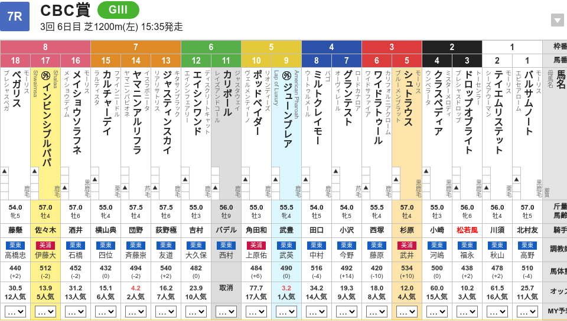

## 4. 単勝予測結果

### 【エルムステークス(GⅢ) 2025/08/09(土)】

| 枠番 | 馬番 | 人気 | オッズ | 馬名 | 騎手 | 調教師 | 予測タイム(sec) | 1_順位 | 1-3着内確率(%) | 2_順位 | ﾀﾞｰｸﾎｰｽ確率(%) | 3_順位 |
| --- | --- | --- | --- | --- | --- | --- | --- | --- | --- | --- | --- | --- |
| 1 | 1 | 5 | 8.9 | ペリエール | 佐々木大輔 | 黒岩陽一 | 107.0 | 4 | 25.3 | 1 | 1.7 | 8 |
| 2 | 2 | 10 | 41.8 | ミッキーヌチバナ | 鮫島克駿 | 高橋亮 | 109.7 | 11 | 5.7 | 11 | 27.1 | 1 |
| 3 | 3 | 2 | 7.0 | ドゥラエレーデ | 松山弘平 | 池添学 | 110.2 | 13 | 17.5 | 4 | 1.2 | 11 |
| 3 | 4 | 12 | 67.7 | スレイマン | 浜中俊 | 池添学 | 110.5 | 14 | 5.6 | 12 | 7.6 | 6 |
| 4 | 5 | 3 | 7.5 | マテンロウスカイ | 横山典弘 | 松永幹夫 | 107.3 | 5 | 10.5 | 8 | 0.9 | 13 |
| 4 | 6 | 1 | 2.6 | ロードクロンヌ | 藤岡佑介 | 四位洋文 | 100.9 | 1 | 24.3 | 2 | 0.5 | 14 |
| 5 | 7 | 9 | 18.6 | テーオードレフォン | 丸山元気 | 梅田智之 | 108.7 | 10 | 16.4 | 5 | 22.4 | 2 |
| 5 | 8 | 7 | 12.4 | ペイシャエス | 横山和生 | 小西一男 | 107.5 | 6 | 6.1 | 10 | 1.0 | 12 |
| 6 | 9 | 11 | 45.4 | ヴァルツァーシャル | 古川吉洋 | 高木登 | 107.5 | 8 | 3.7 | 13 | 6.0 | 7 |
| 6 | 10 | 4 | 8.5 | トロヴァトーレ | Ｃ．ルメール | 鹿戸雄一 | 104.9 | 2 | 21.9 | 3 | 1.4 | 10 |

[output cut: 4 more lines]

### 【レパードステークス(GⅢ) 2025/08/10(日)】

| 枠番 | 馬番 | 人気 | オッズ | 馬名 | 騎手 | 調教師 | 予測タイム(sec) | 1_順位 | 1-3着内確率(%) | 2_順位 | ﾀﾞｰｸﾎｰｽ確率(%) | 3_順位 |
| --- | --- | --- | --- | --- | --- | --- | --- | --- | --- | --- | --- | --- |
| 1 | 1 | 5 | 8.9 | ドンインザムード | 松山弘平 | 今野貞一 | 116.7 | 13.5 | 20.3 | 4 | 2.0 | 8 |
| 2 | 2 | 12 | 43.8 | ルヴァンユニベール | 内田博幸 | 北出成人 | 116.7 | 7.5 | 8.8 | 10 | 39.5 | 3 |
| 2 | 3 | 13 | 58.5 | タガノマカシヤ | 菊沢一樹 | 中村直也 | 116.7 | 7.5 | 8.1 | 13 | 43.1 | 1 |
| 3 | 4 | 7 | 11.8 | ポールセン | 斎藤新 | 斎藤誠 | 116.7 | 7.5 | 17.6 | 6 | 2.0 | 9 |
| 3 | 5 | 8 | 27.7 | シンビリーブ | 菅原明良 | 森秀行 | 116.7 | 7.5 | 9.5 | 9 | 1.9 | 11 |
| 4 | 6 | 6 | 9.3 | ジャナドリア | 戸崎圭太 | 武井亮 | 116.7 | 13.5 | 17.8 | 5 | 1.9 | 10 |
| 4 | 7 | 14 | 71.5 | チュウジョウ | 丸山元気 | 杉山佳明 | 116.7 | 7.5 | 7.6 | 14 | 43.0 | 2 |
| 5 | 8 | 9 | 28.9 | サノノワンダー | 大野拓弥 | 栗田徹 | 116.7 | 7.5 | 8.5 | 11 | 28.5 | 7 |
| 5 | 9 | 3 | 5.5 | ロードラビリンス | 川田将雅 | 松下武士 | 116.6 | 3.0 | 34.4 | 2 | 0.4 | 13 |
| 6 | 10 | 1 | 4.7 | ヴィンセンシオ | Ｃ．ルメール | 森一誠 | 110.3 | 1.0 | 16.8 | 7 | 0.4 | 15 |

[output cut: 5 more lines]

### 【CBC賞(GⅢ) 2025/08/10(日)】

| 枠番 | 馬番 | 人気 | オッズ | 馬名 | 騎手 | 調教師 | 予測タイム(sec) | 1_順位 | 1-3着内確率(%) | 2_順位 | ﾀﾞｰｸﾎｰｽ確率(%) | 3_順位 |
| --- | --- | --- | --- | --- | --- | --- | --- | --- | --- | --- | --- | --- |
| 1 | 1 | 11 | 25.7 | バルサムノート | 北村友一 | 高野友和 | 74.8 | 15 | 3.5 | 13 | 29.3 | 3 |
| 1 | 2 | 16 | 61.5 | テイエムリステット | 川須栄彦 | 秋山真一郎 | 73.9 | 11 | 2.0 | 17 | 12.3 | 6 |
| 2 | 3 | 3 | 10.2 | ドロップオブライト | 松若風馬 | 福永祐一 | 74.1 | 12 | 7.1 | 9 | 0.7 | 15 |
| 2 | 4 | 15 | 60.0 | クラスペディア | 小崎綾也 | 河嶋宏樹 | 71.9 | 9 | 4.2 | 12 | 37.3 | 1 |
| 3 | 5 | 4 | 12.0 | シュトラウス | 杉原誠人 | 武井亮 | 71.8 | 8 | 41.4 | 2 | 1.6 | 9 |
| 3 | 6 | 8 | 18.0 | ワイドラトゥール | 西塚洸二 | 藤原英昭 | 71.0 | 5 | 8.8 | 7 | 1.5 | 10 |
| 4 | 7 | 9 | 19.3 | グランテスト | 小沢大仁 | 今野貞一 | 73.7 | 10 | 6.1 | 11 | 1.4 | 11 |
| 4 | 8 | 14 | 34.2 | ミルトクレイモー | 田口貫太 | 中村直也 | 75.2 | 16 | 2.9 | 14 | 24.9 | 5 |
| 5 | 9 | 1 | 3.2 | ジューンブレア | 武豊 | 武英智 | 67.0 | 1 | 19.8 | 3 | 0.5 | 16 |
| 5 | 10 | 17 | 77.7 | ポッドベイダー | 角田大和 | 上原佑紀 | 70.7 | 4 | 6.9 | 10 | 37.0 | 2 |

[output cut: 7 more lines]

## 5. 人気と着順の乖離率推移

### 【エルムステークス_1997y_2019y】

[interactive chart not shown]

### 【レパードステークス_2011y_2019y】

[interactive chart not shown]

### 【CBC賞_1990y_2019y】

[interactive chart not shown]

### 【エルムステークス_1997y_2019y】

| No | 開催年 | 不整合率(%) | 頭数 | 人気別着順(1-3位) | 人気別着順(全体) |
| --- | --- | --- | --- | --- | --- |
| 23 | 2019 | 46.2 | 14頭 | 2-10-4 | 2\|10\|4\|7\|3\|5\|1\|6\|14\|11\|8\|12\|13\|9 |
| 22 | 2018 | 32.4 | 14頭 | 2-3-1 | 2\|3\|1\|5\|7\|4\|11\|8\|10\|9\|14\|12\|6\|13 |
| 21 | 2017 | 32.3 | 14頭 | 4-1-8 | 4\|1\|8\|6\|13\|10\|2\|7\|12\|3\|9\|5\|11\|14 |
| 20 | 2016 | 45.5 | 12頭 | 7-4-1 | 7\|4\|1\|3\|8\|6\|2\|12\|11\|10\|9\|5 |
| 19 | 2015 | 31.6 | 13頭 | 2-5-7 | 2\|5\|7\|1\|3\|11\|6\|10\|8\|12\|13\|4\|9 |
| 18 | 2014 | 47.5 | 13頭 | 3-5-10 | 3\|5\|10\|12\|13\|1\|4\|7\|8\|2\|6\|11\|9 |
| 17 | 2013 | 48.9 | 13頭 | 3-5-1 | 3\|5\|1\|7\|4\|10\|9\|12\|6\|13\|11\|2\|8 |
| 16 | 2012 | 21.5 | 11頭 | 1-2-6 | 1\|2\|6\|4\|9\|8\|7\|5\|3\|10\|11 |
| 15 | 2011 | 34.3 | 13頭 | 1-8-3 | 1\|8\|3\|5\|4\|7\|6\|13\|9\|10\|2\|11\|12 |
| 14 | 2010 | 28.3 | 13頭 | 2-4-1 | 2\|4\|1\|13\|3\|6\|7\|5\|12\|9\|10\|8\|11 |

[output cut: 13 more lines]

### 【レパードステークス_2011y_2019y】

| No | 開催年 | 不整合率(%) | 頭数 | 人気別着順(1-3位) | 人気別着順(全体) |
| --- | --- | --- | --- | --- | --- |
| 9 | 2019 | 28.1 | 15頭 | 10-1-11 | 10\|1\|11\|7\|3\|2\|12\|9\|13\|4\|5\|8\|6\|14\|15 |
| 8 | 2018 | 43.0 | 15頭 | 5-10-9 | 5\|10\|9\|2\|4\|1\|11\|14\|3\|12\|6\|7\|8\|13\|15 |
| 7 | 2017 | 41.3 | 14頭 | 11-12-1 | 11\|12\|1\|13\|8\|4\|3\|9\|5\|7\|10\|2\|15\|6 |
| 6 | 2016 | 29.6 | 13頭 | 2-1-6 | 2\|1\|6\|4\|13\|5\|3\|10\|11\|8\|7\|12\|9 |
| 5 | 2015 | 23.5 | 14頭 | 1-3-11 | 1\|3\|11\|2\|6\|5\|12\|4\|8\|7\|14\|13\|15\|9 |
| 4 | 2014 | 13.6 | 15頭 | 1-7-9 | 1\|7\|9\|2\|3\|4\|10\|8\|12\|5\|14\|13\|15\|6\|11 |
| 3 | 2013 | 17.1 | 15頭 | 1-4-2 | 1\|4\|2\|3\|13\|6\|8\|9\|5\|11\|7\|15\|12\|14\|10 |
| 2 | 2012 | 30.0 | 15頭 | 2-3-1 | 2\|3\|1\|4\|10\|6\|12\|5\|13\|8\|14\|9\|11\|7\|15 |
| 1 | 2011 | 18.3 | 15頭 | 1-2-12 | 1\|2\|12\|3\|10\|7\|8\|6\|14\|5\|13\|11\|4\|9\|15 |

### 【CBC賞_1990y_2019y】

| No | 開催年 | 不整合率(%) | 頭数 | 人気別着順(1-3位) | 人気別着順(全体) |
| --- | --- | --- | --- | --- | --- |
| 30 | 2019 | 21.5 | 13頭 | 1-7-2 | 1\|7\|2\|8\|5\|6\|11\|3\|12\|9\|10\|4\|13 |
| 29 | 2018 | 59.6 | 18頭 | 4-9-8 | 4\|9\|8\|3\|13\|15\|10\|11\|6\|14\|1\|12\|7\|18\|2\|5\|17\|16 |
| 28 | 2017 | 30.9 | 18頭 | 2-13-8 | 2\|13\|8\|9\|12\|15\|17\|11\|16\|1\|3\|10\|4\|6\|14\|5\|7\|18 |
| 27 | 2016 | 63.8 | 13頭 | 3-7-2 | 3\|7\|2\|6\|10\|5\|8\|4\|1\|13\|11\|9\|12 |
| 26 | 2015 | 22.4 | 17頭 | 2-1-3 | 2\|1\|3\|5\|17\|14\|9\|8\|4\|12\|15\|6\|13\|11\|16\|7\|10 |
| 25 | 2014 | 51.7 | 16頭 | 4-3-10 | 4\|3\|10\|9\|1\|8\|15\|2\|6\|7\|16\|11\|13\|14\|12\|5 |
| 24 | 2013 | 7.4 | 14頭 | 1-2-3 | 1\|2\|3\|5\|4\|8\|7\|10\|11\|6\|14\|9\|12\|13 |
| 23 | 2012 | 32.0 | 17頭 | 2-7-1 | 2\|7\|1\|8\|4\|10\|5\|6\|3\|9\|12\|15\|13\|16\|17\|14\|11 |
| 22 | 2011 | 33.9 | 16頭 | 1-4-13 | 1\|4\|13\|5\|3\|6\|7\|2\|12\|9\|10\|15\|14\|11\|8\|16 |
| 21 | 2010 | 57.5 | 18頭 | 4-7-3 | 4\|7\|3\|12\|13\|1\|10\|8\|11\|6\|18\|16\|5\|2\|17\|14\|15\|9 |

[output cut: 20 more lines]

## 6. 1-3番人気馬の着順分類予測

### 【エルムステークス】

| 分類 | 凡例 | 発生確率(%) | 当該レース | 当該レースランク | 直近1年間 |
| --- | --- | --- | --- | --- | --- |
| 1: 1番人気のみ (1_pop1) | 1 \| * \| * | 17.2 | 1.20 | 0.81 | 0.52 |
| 4: 1,2番人気のみ (4_pop12) | 1 \| 2 \| * | 16.4 | 0.92 | 0.67 | 0.49 |
| 8: 1,2,3番人気すべて着外 (8_darkhorse) | * \| * \| * | 14.2 | 3.94 | 2.15 | 0.00 |
| 5: 1,3番人気のみ (5_pop13) | 1 \| 3 \| * | 14.0 | 1.31 | 2.12 | 0.00 |
| 2: 2番人気のみ (2_pop2) | 2 \| * \| * | 12.1 | 0.38 | 0.61 | 0.36 |
| 6: 2,3番人気のみ (6_pop23) | 2 \| 3 \| * | 9.8 | 2.72 | 2.97 | 0.00 |
| 3: 3番人気のみ (3_pop3) | 3 \| * \| * | 9.3 | 0.87 | 0.95 | 0.00 |
| 7: 1,2,3番人気すべて着内 (7_pop123) | 1 \| 2 \| 3 | 7.0 | 0.99 | 0.85 | 0.00 |

### 【レパードステークス】

| 分類 | 凡例 | 発生確率(%) | 当該レース | 当該レースランク | 直近1年間 |
| --- | --- | --- | --- | --- | --- |
| 1: 1番人気のみ (1_pop1) | 1 \| * \| * | 17.2 | 0.30 | 0.63 | 0.34 |
| 4: 1,2番人気のみ (4_pop12) | 1 \| 2 \| * | 16.4 | 0.77 | 0.54 | 0.33 |
| 8: 1,2,3番人気すべて着外 (8_darkhorse) | * \| * \| * | 14.2 | 2.00 | 1.56 | 0.00 |
| 5: 1,3番人気のみ (5_pop13) | 1 \| 3 \| * | 14.0 | 1.97 | 4.67 | 0.00 |
| 2: 2番人気のみ (2_pop2) | 2 \| * \| * | 12.1 | 0.00 | 1.33 | 0.00 |
| 6: 2,3番人気のみ (6_pop23) | 2 \| 3 \| * | 9.8 | 0.00 | 3.27 | 0.00 |
| 3: 3番人気のみ (3_pop3) | 3 \| * \| * | 9.3 | 0.00 | 1.02 | 0.00 |
| 7: 1,2,3番人気すべて着内 (7_pop123) | 1 \| 2 \| 3 | 7.0 | 0.99 | 0.77 | 0.00 |

### 【CBC賞】

| 分類 | 凡例 | 発生確率(%) | 当該レース | 当該レースランク | 直近1年間 |
| --- | --- | --- | --- | --- | --- |
| 1: 1番人気のみ (1_pop1) | 1 \| * \| * | 17.8 | 1.56 | 0.65 | 0.36 |
| 4: 1,2番人気のみ (4_pop12) | 1 \| 2 \| * | 16.7 | 0.58 | 0.55 | 0.33 |
| 5: 1,3番人気のみ (5_pop13) | 1 \| 3 \| * | 14.6 | 2.56 | 4.87 | 0.00 |
| 8: 1,2,3番人気すべて着外 (8_darkhorse) | * \| * \| * | 14.4 | 1.67 | 1.58 | 0.00 |
| 6: 2,3番人気のみ (6_pop23) | 2 \| 3 \| * | 10.0 | 1.75 | 3.33 | 0.00 |
| 2: 2番人気のみ (2_pop2) | 2 \| * \| * | 9.9 | 0.87 | 1.09 | 0.00 |
| 3: 3番人気のみ (3_pop3) | 3 \| * \| * | 9.5 | 0.66 | 1.04 | 0.00 |
| 7: 1,2,3番人気すべて着内 (7_pop123) | 1 \| 2 \| 3 | 7.2 | 0.50 | 0.79 | 0.00 |

## 7. 3連複予測結果

### 【エルムステークス(GⅢ) 2025/08/09(土)】

| 分類 | 馬番 | 枠番 | 人気 | 平均予測タイム(sec) | 1-3着内確率(%) | ﾀﾞｰｸﾎｰｽ確率(%) | 馬名 | 騎手 | 調教師 |
| --- | --- | --- | --- | --- | --- | --- | --- | --- | --- |
| 1: 1番人気のみ (1_pop1) | 6-10-1 | 4-6-1 | 1-4-5 | 104.27 | 1.35 | 0.00 | ロードクロンヌ \| トロヴァトーレ \| ペリエール | 藤岡佑介 \| Ｃ．ルメール \| 佐々木大輔 | 四位洋文 \| 鹿戸雄一 \| 黒岩陽一 |
| 4: 1,2番人気のみ (4_pop12) | 6-3-1 | 4-3-1 | 1-2-5 | 106.03 | 1.08 | 0.00 | ロードクロンヌ \| ドゥラエレーデ \| ペリエール | 藤岡佑介 \| 松山弘平 \| 佐々木大輔 | 四位洋文 \| 池添学 \| 黒岩陽一 |
| 1: 1番人気のみ (1_pop1) | 6-1-7 | 4-1-5 | 1-5-9 | 105.53 | 1.01 | 0.00 | ロードクロンヌ \| ペリエール \| テーオードレフォン | 藤岡佑介 \| 佐々木大輔 \| 丸山元気 | 四位洋文 \| 黒岩陽一 \| 梅田智之 |
| 2: 2番人気のみ (2_pop2) | 3-10-1 | 3-6-1 | 2-4-5 | 107.37 | 0.97 | 0.00 | ドゥラエレーデ \| トロヴァトーレ \| ペリエール | 松山弘平 \| Ｃ．ルメール \| 佐々木大輔 | 池添学 \| 鹿戸雄一 \| 黒岩陽一 |
| 1: 1番人気のみ (1_pop1) | 6-1-11 | 4-1-7 | 1-5-6 | 104.93 | 0.96 | 0.00 | ロードクロンヌ \| ペリエール \| ブライアンセンス | 藤岡佑介 \| 佐々木大輔 \| 丹内祐次 | 四位洋文 \| 黒岩陽一 \| 斎藤誠 |
| 4: 1,2番人気のみ (4_pop12) | 6-3-10 | 4-3-6 | 1-2-4 | 105.33 | 0.94 | 0.00 | ロードクロンヌ \| ドゥラエレーデ \| トロヴァトーレ | 藤岡佑介 \| 松山弘平 \| Ｃ．ルメール | 四位洋文 \| 池添学 \| 鹿戸雄一 |
| 8: 1,2,3番人気すべて着外 (8_darkhorse) | 10-1-7 | 6-1-5 | 4-5-9 | 106.87 | 0.91 | 0.01 | トロヴァトーレ \| ペリエール \| テーオードレフォン | Ｃ．ルメール \| 佐々木大輔 \| 丸山元気 | 鹿戸雄一 \| 黒岩陽一 \| 梅田智之 |
| 1: 1番人気のみ (1_pop1) | 6-10-7 | 4-6-5 | 1-4-9 | 104.83 | 0.87 | 0.00 | ロードクロンヌ \| トロヴァトーレ \| テーオードレフォン | 藤岡佑介 \| Ｃ．ルメール \| 丸山元気 | 四位洋文 \| 鹿戸雄一 \| 梅田智之 |
| 8: 1,2,3番人気すべて着外 (8_darkhorse) | 10-1-11 | 6-1-7 | 4-5-6 | 106.27 | 0.87 | 0.00 | トロヴァトーレ \| ペリエール \| ブライアンセンス | Ｃ．ルメール \| 佐々木大輔 \| 丹内祐次 | 鹿戸雄一 \| 黒岩陽一 \| 斎藤誠 |
| 1: 1番人気のみ (1_pop1) | 6-1-14 | 4-1-8 | 1-5-8 | 105.97 | 0.86 | 0.00 | ロードクロンヌ \| ペリエール \| ウィリアムバローズ | 藤岡佑介 \| 佐々木大輔 \| 横山武史 | 四位洋文 \| 黒岩陽一 \| 上村洋行 |

[output cut: 354 more lines]

### 【レパードステークス(GⅢ) 2025/08/10(日)】

| 分類 | 馬番 | 枠番 | 人気 | 平均予測タイム(sec) | 1-3着内確率(%) | ﾀﾞｰｸﾎｰｽ確率(%) | 馬名 | 騎手 | 調教師 |
| --- | --- | --- | --- | --- | --- | --- | --- | --- | --- |
| 6: 2,3番人気のみ (6_pop23) | 13-9-12 | 7-5-7 | 2-3-4 | 116.70 | 3.72 | 0.00 | ルグランヴァン \| ロードラビリンス \| トリポリタニア | 原優介 \| 川田将雅 \| 岩田康誠 | 高木登 \| 松下武士 \| 上村洋行 |
| 6: 2,3番人気のみ (6_pop23) | 13-9-1 | 7-5-1 | 2-3-5 | 116.70 | 3.27 | 0.00 | ルグランヴァン \| ロードラビリンス \| ドンインザムード | 原優介 \| 川田将雅 \| 松山弘平 | 高木登 \| 松下武士 \| 今野貞一 |
| 6: 2,3番人気のみ (6_pop23) | 13-9-6 | 7-5-4 | 2-3-6 | 116.70 | 2.86 | 0.00 | ルグランヴァン \| ロードラビリンス \| ジャナドリア | 原優介 \| 川田将雅 \| 戸崎圭太 | 高木登 \| 松下武士 \| 武井亮 |
| 6: 2,3番人気のみ (6_pop23) | 13-9-4 | 7-5-3 | 2-3-7 | 116.70 | 2.83 | 0.00 | ルグランヴァン \| ロードラビリンス \| ポールセン | 原優介 \| 川田将雅 \| 斎藤新 | 高木登 \| 松下武士 \| 斎藤誠 |
| 7: 1,2,3番人気すべて着内 (7_pop123) | 10-13-9 | 6-7-5 | 1-2-3 | 114.57 | 2.71 | 0.00 | ヴィンセンシオ \| ルグランヴァン \| ロードラビリンス | Ｃ．ルメール \| 原優介 \| 川田将雅 | 森一誠 \| 高木登 \| 松下武士 |
| 2: 2番人気のみ (2_pop2) | 13-12-1 | 7-7-1 | 2-4-5 | 116.73 | 2.19 | 0.00 | ルグランヴァン \| トリポリタニア \| ドンインザムード | 原優介 \| 岩田康誠 \| 松山弘平 | 高木登 \| 上村洋行 \| 今野貞一 |
| 2: 2番人気のみ (2_pop2) | 13-12-6 | 7-7-4 | 2-4-6 | 116.73 | 1.92 | 0.00 | ルグランヴァン \| トリポリタニア \| ジャナドリア | 原優介 \| 岩田康誠 \| 戸崎圭太 | 高木登 \| 上村洋行 \| 武井亮 |
| 2: 2番人気のみ (2_pop2) | 13-12-4 | 7-7-3 | 2-4-7 | 116.73 | 1.90 | 0.00 | ルグランヴァン \| トリポリタニア \| ポールセン | 原優介 \| 岩田康誠 \| 斎藤新 | 高木登 \| 上村洋行 \| 斎藤誠 |
| 6: 2,3番人気のみ (6_pop23) | 13-9-11 | 7-5-6 | 2-3-11 | 116.70 | 1.87 | 0.00 | ルグランヴァン \| ロードラビリンス \| ヒルノハンブルク | 原優介 \| 川田将雅 \| 石橋脩 | 高木登 \| 松下武士 \| 武英智 |
| 4: 1,2番人気のみ (4_pop12) | 10-13-12 | 6-7-7 | 1-2-4 | 114.60 | 1.81 | 0.00 | ヴィンセンシオ \| ルグランヴァン \| トリポリタニア | Ｃ．ルメール \| 原優介 \| 岩田康誠 | 森一誠 \| 高木登 \| 上村洋行 |

[output cut: 445 more lines]

### 【CBC賞(GⅢ) 2025/08/10(日)】

| 分類 | 馬番 | 枠番 | 人気 | 平均予測タイム(sec) | 1-3着内確率(%) | ﾀﾞｰｸﾎｰｽ確率(%) | 馬名 | 騎手 | 調教師 |
| --- | --- | --- | --- | --- | --- | --- | --- | --- | --- |
| 4: 1,2番人気のみ (4_pop12) | 9-14-5 | 5-7-3 | 1-2-4 | 69.77 | 3.67 | 0.00 | ジューンブレア \| ヤマニンアルリフラ \| シュトラウス | 武豊 \| 団野大成 \| 杉原誠人 | 武英智 \| 斉藤崇史 \| 武井亮 |
| 2: 2番人気のみ (2_pop2) | 14-5-17 | 7-3-8 | 2-4-5 | 71.13 | 2.65 | 0.00 | ヤマニンアルリフラ \| シュトラウス \| インビンシブルパパ | 団野大成 \| 杉原誠人 \| 佐々木大輔 | 斉藤崇史 \| 武井亮 \| 伊藤大士 |
| 2: 2番人気のみ (2_pop2) | 14-5-15 | 7-3-7 | 2-4-6 | 71.33 | 2.60 | 0.00 | ヤマニンアルリフラ \| シュトラウス \| カルチャーデイ | 団野大成 \| 杉原誠人 \| 横山典弘 | 斉藤崇史 \| 武井亮 \| 四位洋文 |
| 2: 2番人気のみ (2_pop2) | 14-5-13 | 7-3-7 | 2-4-7 | 72.70 | 2.17 | 0.00 | ヤマニンアルリフラ \| シュトラウス \| ジャスティンスカイ | 団野大成 \| 杉原誠人 \| 荻野極 | 斉藤崇史 \| 武井亮 \| 友道康夫 |
| 2: 2番人気のみ (2_pop2) | 14-5-6 | 7-3-3 | 2-4-8 | 71.10 | 1.63 | 0.00 | ヤマニンアルリフラ \| シュトラウス \| ワイドラトゥール | 団野大成 \| 杉原誠人 \| 西塚洸二 | 斉藤崇史 \| 武井亮 \| 藤原英昭 |
| 2: 2番人気のみ (2_pop2) | 14-5-12 | 7-3-6 | 2-4-10 | 70.90 | 1.43 | 0.00 | ヤマニンアルリフラ \| シュトラウス \| エイシンワンド | 団野大成 \| 杉原誠人 \| 吉村誠之助 | 斉藤崇史 \| 武井亮 \| 大久保龍志 |
| 6: 2,3番人気のみ (6_pop23) | 14-3-5 | 7-2-3 | 2-3-4 | 72.13 | 1.32 | 0.00 | ヤマニンアルリフラ \| ドロップオブライト \| シュトラウス | 団野大成 \| 松若風馬 \| 杉原誠人 | 斉藤崇史 \| 福永祐一 \| 武井亮 |
| 2: 2番人気のみ (2_pop2) | 14-5-10 | 7-3-5 | 2-4-17 | 71.00 | 1.28 | 0.00 | ヤマニンアルリフラ \| シュトラウス \| ポッドベイダー | 団野大成 \| 杉原誠人 \| 角田大和 | 斉藤崇史 \| 武井亮 \| 上原佑紀 |
| 4: 1,2番人気のみ (4_pop12) | 9-14-17 | 5-7-8 | 1-2-5 | 69.53 | 1.27 | 0.00 | ジューンブレア \| ヤマニンアルリフラ \| インビンシブルパパ | 武豊 \| 団野大成 \| 佐々木大輔 | 武英智 \| 斉藤崇史 \| 伊藤大士 |
| 4: 1,2番人気のみ (4_pop12) | 9-14-15 | 5-7-7 | 1-2-6 | 69.73 | 1.24 | 0.00 | ジューンブレア \| ヤマニンアルリフラ \| カルチャーデイ | 武豊 \| 団野大成 \| 横山典弘 | 武英智 \| 斉藤崇史 \| 四位洋文 |

[output cut: 670 more lines]

## 8. 直近の全レース情報

[output not shown]